# Practical Machine Learning Course Project

Jerome Cholewa

January 15th 2017

## Introduction and methodology

This study’s purpose is to predict how well the subjects exercized based on data collected by sensors placed on their body and on their training tools (dumbbells, …). More information is available on the http://groupware.les.inf.puc-rio.br/har (see the section on the Weight Lifting Exercise Dataset).

First I did some exploratory analysis of the training data That quickly showed that some variables did not yield any useable information (either had no data like “”, or DIV0# or NA). I will come to that in more details below. It was not until my first attempt to predict the outcome with the testing data that I realized that the testing data itself had a lot of variables with only NA’s. I then decided to go back to my training data and deleted these variables too, since they would be useless to predict anything. That narrowed down the number of variables significantly from 159 (excluding the outcome **class**) from less than 60, which made the `train()` method work much faster.

## Exploratory analysis

We need to use certain packages for that analysis.

```r
library(caret)
library(lubridate)
library(randomForest)
```

In order to speed up the calculation, I used multi-core usage:

```r
library(doParallel)
cluster <- makeCluster(detectCores() - 1) # convention to leave 1 core for OS
registerDoParallel(cluster)
```

Read the data in:

```r
training <- read.csv("~/Documents/Education/Coursera/Datascience with R/8.Machine Learning/Assignment/pml-training.csv")
testing <- read.csv("~/Documents/Education/Coursera/Datascience with R/8.Machine Learning/Assignment/pml-testing.csv")
```

Upon plotting some variables, I detected outliers. Here I am giving an example of the **x** axis but the **y** and **z** axis had one outlier exactly on the same row (**5373**), therefore I decided to remove that row.

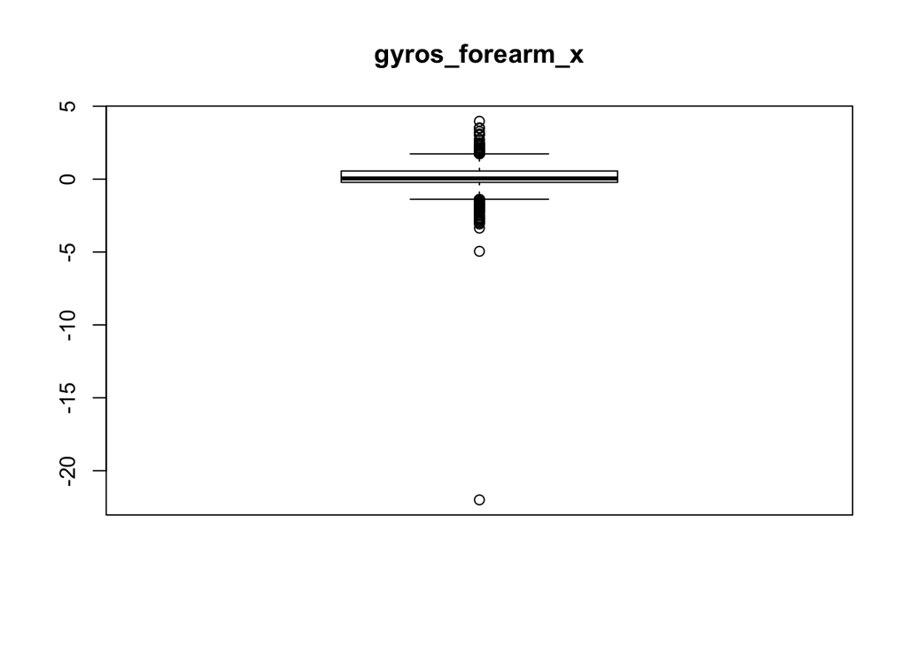

```r
par(mfrow = c(1,1))
boxplot(training$gyros_forearm_x)
title("gyros_forearm_x")
```

```r
training <- training[-5373,]
```

Then I concluded that the first 4 variables could not have any impact whatsoever in the prediction: X, user_name and the 2 raw time stamps)

```r
training <-  training[,-c(1, 2,3,4)]
```

Now I decided to have a look at the **testing** data (since anyway the last column is NOT the outcome). I saw that lots of columns actually contained only NA’s. Therefore I decided to remove these columns from the **training** data since they would be useless to predict the **testibg** data. Later I will remove those same columns from the **testing** data.

```r
summary(testing)  # can easiy see whether some variables are full of NA's
training <- within(training, rm(new_window, num_window,kurtosis_roll_belt, kurtosis_picth_belt,
                                kurtosis_yaw_belt, skewness_roll_belt, skewness_roll_belt.1,
                                skewness_yaw_belt, max_roll_belt, max_picth_belt, max_yaw_belt, min_roll_belt,
                                min_pitch_belt, min_yaw_belt, amplitude_roll_belt, amplitude_pitch_belt,
                                amplitude_yaw_belt, var_total_accel_belt, avg_roll_belt,
                                stddev_roll_belt, var_roll_belt, avg_pitch_belt, stddev_pitch_belt,
                                var_pitch_belt, avg_yaw_belt, stddev_yaw_belt, var_yaw_belt,
                                var_accel_arm, avg_roll_arm, stddev_roll_arm, var_roll_arm, avg_pitch_arm,
                                stddev_pitch_arm, var_pitch_arm, avg_yaw_arm, stddev_yaw_arm, var_yaw_arm,
                                kurtosis_roll_arm, kurtosis_picth_arm, kurtosis_yaw_arm,
                                skewness_roll_arm, skewness_pitch_arm, skewness_yaw_arm,
                                max_roll_arm, max_picth_arm, max_yaw_arm, min_roll_arm, min_pitch_arm,
                                min_yaw_arm, amplitude_roll_arm, amplitude_pitch_arm, amplitude_yaw_arm,
                                kurtosis_roll_dumbbell, kurtosis_picth_dumbbell, kurtosis_yaw_dumbbell,
                                skewness_roll_dumbbell, skewness_pitch_dumbbell, skewness_yaw_dumbbell,
                                max_roll_dumbbell, max_picth_dumbbell, max_yaw_dumbbell,
                                min_roll_dumbbell, min_pitch_dumbbell, min_yaw_dumbbell,
                                amplitude_roll_dumbbell, amplitude_pitch_dumbbell, amplitude_yaw_dumbbell,
                                var_accel_dumbbell, avg_roll_dumbbell, stddev_roll_dumbbell,
                                var_roll_dumbbell, avg_pitch_dumbbell, stddev_pitch_dumbbell,
                                var_pitch_dumbbell, avg_yaw_dumbbell, stddev_yaw_dumbbell,
                                var_yaw_dumbbell, kurtosis_roll_forearm, kurtosis_picth_forearm,
                                kurtosis_yaw_forearm, skewness_roll_forearm, skewness_pitch_forearm,
                                skewness_yaw_forearm, max_roll_forearm, max_picth_forearm,
                                max_yaw_forearm, min_roll_forearm, min_pitch_forearm, min_yaw_forearm,
                                amplitude_roll_forearm, amplitude_pitch_forearm, amplitude_yaw_forearm,
                                var_accel_forearm, avg_roll_forearm, stddev_roll_forearm,
                                var_roll_forearm, avg_pitch_forearm, stddev_pitch_forearm,
                                var_pitch_forearm, avg_yaw_forearm, stddev_yaw_forearm,
                                var_yaw_forearm))
```

Let’s convert the time stamp from factor to time stamp

```r
training$cvtd_timestamp <- parse_date_time(training$cvtd_timestamp,orders = "dmy HM")
```

A quick look at the remaining columns of the **training** data shows that now there are no more factor variables except the “classe” column

Let’s analyze the time series to find patterns. Offline I checked many plots. Here I am showing only 3 to illustrate my point.

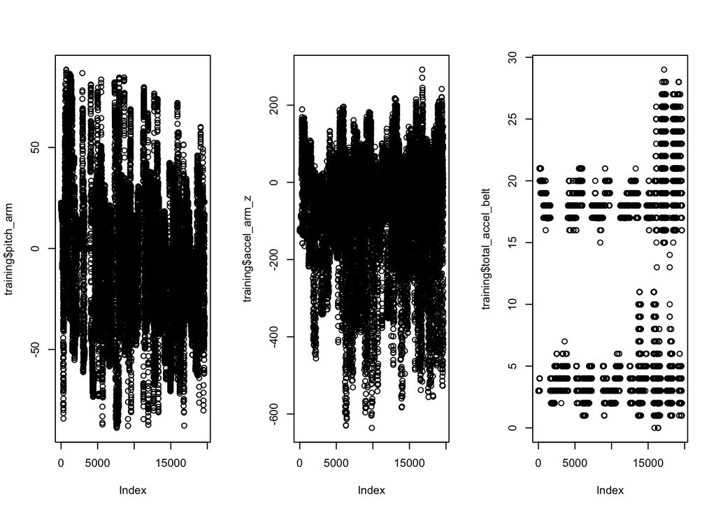

```r
par(mfrow = c(1,3))
plot(training$pitch_arm)
plot(training$accel_arm_z)
plot(training$total_accel_belt)
```

Since there are no time patterns I remove the time stamp column

```r
training <- within(training, rm( cvtd_timestamp))
```

The remaining columns have mo more NA’s

```r
colSums(training[,-53]) # no NA's
```

```
##            roll_belt           pitch_belt             yaw_belt
##           1263796.54              5984.31           -219778.31
##     total_accel_belt         gyros_belt_x         gyros_belt_y
##            221973.00              -109.70               776.79
##         gyros_belt_z         accel_belt_x         accel_belt_y
##             -2561.36           -109764.00            591693.00
##         accel_belt_z        magnet_belt_x        magnet_belt_y
##          -1424460.00           1090936.00          11648546.00
##        magnet_belt_z             roll_arm            pitch_arm
##          -6778601.00            349784.76            -90539.40
##              yaw_arm      total_accel_arm          gyros_arm_x
##            -12223.74            500500.00               838.69
##          gyros_arm_y          gyros_arm_z          accel_arm_x
##             -5044.36              5287.71          -1181817.00
##          accel_arm_y          accel_arm_z         magnet_arm_x
##            639464.00          -1397884.00           3762259.00
##         magnet_arm_y         magnet_arm_z        roll_dumbbell
##           3072812.00           6013334.00            467775.32
##       pitch_dumbbell         yaw_dumbbell total_accel_dumbbell
##           -211431.75             32797.14            269124.00
##     gyros_dumbbell_x     gyros_dumbbell_y     gyros_dumbbell_z
##              3364.80               851.72             -2848.02
##     accel_dumbbell_x     accel_dumbbell_y     accel_dumbbell_z
##           -561078.00           1032531.00           -752272.00
##    magnet_dumbbell_x    magnet_dumbbell_y    magnet_dumbbell_z
##          -6445321.00           4335845.00            903596.00
##         roll_forearm        pitch_forearm          yaw_forearm
##            663743.80            210073.05            376891.83
##  total_accel_forearm      gyros_forearm_x      gyros_forearm_y
##            681076.00              3121.32              1164.08
##      gyros_forearm_z      accel_forearm_x      accel_forearm_y
##              2736.73          -1209339.00           3210333.00
##      accel_forearm_z     magnet_forearm_x     magnet_forearm_y
##          -1084600.00          -6133364.00           7458645.00
##     magnet_forearm_z
##           7723489.00
```

Let’s start the analysis, first by setting the seed and using the **randomForest**.

```r
set.seed(1423)
fit_rf <- randomForest(classe ~ .,method="rf",data=training, ntree = 200)
predic_rf <- predict(fit_rf, training)
confusionMatrix(predic_rf,    training$classe) # perfect with 200 trees
```

```
## Confusion Matrix and Statistics
##
##           Reference
## Prediction    A    B    C    D    E
##          A 5579    0    0    0    0
##          B    0 3797    0    0    0
##          C    0    0 3422    0    0
##          D    0    0    0 3216    0
##          E    0    0    0    0 3607
##
## Overall Statistics
##
##                Accuracy : 1
##                  95% CI : (0.9998, 1)
##     No Information Rate : 0.2843
##     P-Value [Acc > NIR] : < 2.2e-16
##
##                   Kappa : 1
##  Mcnemar's Test P-Value : NA
##
## Statistics by Class:
##
##                      Class: A Class: B Class: C Class: D Class: E
## Sensitivity            1.0000   1.0000   1.0000   1.0000   1.0000
## Specificity            1.0000   1.0000   1.0000   1.0000   1.0000
## Pos Pred Value         1.0000   1.0000   1.0000   1.0000   1.0000
## Neg Pred Value         1.0000   1.0000   1.0000   1.0000   1.0000
## Prevalence             0.2843   0.1935   0.1744   0.1639   0.1838
## Detection Rate         0.2843   0.1935   0.1744   0.1639   0.1838
## Detection Prevalence   0.2843   0.1935   0.1744   0.1639   0.1838
## Balanced Accuracy      1.0000   1.0000   1.0000   1.0000   1.0000
```

Now let’s clean the **testing** data in a similar way we did for the **training** data.

```r
testing2 <- within(testing, rm(kurtosis_roll_belt, kurtosis_picth_belt, kurtosis_yaw_belt,
                               skewness_roll_belt, skewness_roll_belt.1, skewness_yaw_belt,
                               max_roll_belt, max_picth_belt, max_yaw_belt, min_roll_belt, min_pitch_belt,
                               min_yaw_belt, amplitude_roll_belt, amplitude_pitch_belt,
                               amplitude_yaw_belt, var_total_accel_belt, avg_roll_belt,
                               stddev_roll_belt, var_roll_belt, avg_pitch_belt, stddev_pitch_belt,
                               var_pitch_belt, avg_yaw_belt, stddev_yaw_belt, var_yaw_belt,var_accel_arm,
                               avg_roll_arm, stddev_roll_arm, var_roll_arm, avg_pitch_arm,
                               stddev_pitch_arm, var_pitch_arm, avg_yaw_arm, stddev_yaw_arm, var_yaw_arm,
                               kurtosis_roll_arm, kurtosis_picth_arm, kurtosis_yaw_arm,
                               skewness_roll_arm, skewness_pitch_arm, skewness_yaw_arm,
                               max_roll_arm, max_picth_arm, max_yaw_arm, min_roll_arm, min_pitch_arm,
                               min_yaw_arm, amplitude_roll_arm, amplitude_pitch_arm, amplitude_yaw_arm,
                               kurtosis_roll_dumbbell, kurtosis_picth_dumbbell, kurtosis_yaw_dumbbell,
                               skewness_roll_dumbbell, skewness_pitch_dumbbell, skewness_yaw_dumbbell,
                               max_roll_dumbbell, max_picth_dumbbell, max_yaw_dumbbell,
                               min_roll_dumbbell, min_pitch_dumbbell, min_yaw_dumbbell,
                               amplitude_roll_dumbbell, amplitude_pitch_dumbbell, amplitude_yaw_dumbbell,
                               var_accel_dumbbell, avg_roll_dumbbell, stddev_roll_dumbbell,
                               var_roll_dumbbell, avg_pitch_dumbbell, stddev_pitch_dumbbell,
                               var_pitch_dumbbell, avg_yaw_dumbbell, stddev_yaw_dumbbell,
                               var_yaw_dumbbell, kurtosis_roll_forearm, kurtosis_picth_forearm,
                               kurtosis_yaw_forearm, skewness_roll_forearm, skewness_pitch_forearm,
                               skewness_yaw_forearm, max_roll_forearm, max_picth_forearm,
                               max_yaw_forearm, min_roll_forearm, min_pitch_forearm, min_yaw_forearm,
                               amplitude_roll_forearm, amplitude_pitch_forearm, amplitude_yaw_forearm,
                               var_accel_forearm, avg_roll_forearm, stddev_roll_forearm,
                               var_roll_forearm, avg_pitch_forearm, stddev_pitch_forearm,
                               var_pitch_forearm, avg_yaw_forearm, stddev_yaw_forearm,
                               var_yaw_forearm))
```

```r
testing2 <-  testing2[,-c(1, 2,3,4, 5, 6, 7)]
```

Finally we predict the testing results

```r
predic_rf <- predict(fit_rf, testing2)
predic_rf
```

```
##  1  2  3  4  5  6  7  8  9 10 11 12 13 14 15 16 17 18 19 20
##  B  A  B  A  A  E  D  B  A  A  B  C  B  A  E  E  A  B  B  B
## Levels: A B C D E
```